# Halls Cave Temporal Analysis

Dai Shizuka & Quentin Smith

updated 01/19/25

## Load packages

```r
library(igraph)
library(ggplot2)
library(tidyverse)
library(RColorBrewer)
library(lme4) #package for running mixed-effects models
library(lmerTest) #package for extracting p-values form lme4 models
library(stringr)
library(bipartite)
library(cowplot)
library(ppcor)
library(forcats)
library(dplyr)
library(viridisLite)
```

## Import datasets

- `interval_dat` is the set of species found in each time interval. There are 16 time intervals. Each column is a time interval with species in rows. Columns have different number of rows. *Note that the time intervals are ordered in reverse chronological order, so that the most recent interval is first*
- `climate_dat` contains some climate variables for each time interval. *double check this* but Variables include means and CVs of precipitation, max temperature and min temperature, as well as “calculated average temperature”.
- `mat_raw` is the overall matrix of consumer-resource relationships. Resources are listed in rows and consumers are listed in columns. Note that some species are listed twice–once for Pleistocene and once for Holocene–if their diet at different periods were estimated using stable isotopes. These species are listed with suffix “_pleistocene” and “_holocene” respectively.
- `spp_attrs` is a dataframe that contains attribute information for different species, such as “extinct/extant/introduced” status, mass, and trophic category.

```r
interval_dat=read.csv("New_Data/Time_Intervals_introduced_4-2-2024.csv", check.names = FALSE)
#interval_dat_introduced=read.csv("New_Data/Time_Intervals_3-9-2023.csv", check.names = FALSE)
climate_dat=read.csv("New_Data/Halls Cave Climate Data for 16 Time Intervals.csv", check.names = FALSE)

names(climate_dat) <- iconv(names(climate_dat), to = "ASCII", sub = "")



plei_sites=read.csv("New_Data/Pleistocene_Sites_3-9-2023.csv")

holo_sites=read.csv("New_Data/Holocene_Sites_3-9-2023.csv")

#plei_trophic_mods=read.csv("New_Data/Plei_trophic_mods_9-1-2023.csv")

#holo_trophic_mods=read.csv("New_Data/Holo_trophic_mods_9-13-2023.csv")

#mods_per_bin=read.csv("New_Data/mods_per_bin_4-13-2023.csv")
```

The full matrix, with resources already added:

```r
mat=as.matrix(read.csv("Supplemental Data/full_matrix.csv", row.names=1))
```

The species attributes (added two Mustela species that were not on the original species attributes list, but is in the data).

```r
spp_attrs=read.csv("Supplemental Data/spp_attributes_forGEBsupplement.csv")
```

## Import the list of species for each time unit

```r
load("Supplemental Data/species_lists.rdata")
```

## 2. Generate consumer-resource matrices for each time interval

```r
time.mats=lapply(time.list, function(x) mat[rownames(mat) %in% x, rownames(mat) %in% x])
```

```r
sapply(time.mats, dim)
```

```
##      0-1128ybp 1128-1458ybp 1458-2775ybp 3104-4422ybp 4751-6069ybp 6398-7716ybp
## [1,]        43           36           38           36           31           34
## [2,]        43           36           38           36           31           34
##      8045-9363ybp 9692-11010ybp 11339-12656ybp 12986-14623ybp 14859-15802ybp
## [1,]           38            47             57             60             59
## [2,]           38            47             57             60             59
##      16038-16980ybp 17216-18159ybp 18395-19338ybp 19574-20517ybp 20752-20988ybp
## [1,]             51             40             25             32             29
## [2,]             51             40             25             32             29
```

## 3. Create and analyzing foodweb networks

### 3.1. Creating the whole foodweb network for each time interval.

We will use the igraph package functions to create networks from the consumer-resource matrices for each time interval. These will be “directed networks” with arrows going from resource to consumer, representing energy flow.

While we are converting the matrices into networks, we will also import trophic category as vertex attributes from the `spp_attrs` dataframe using a match function to look up the species.

```r
#Make a foodweb network of each interval
time_nets=list()
for(i in 1:length(time.mats)){
  time_nets[[i]]=graph_from_adjacency_matrix(time.mats[[i]], "directed")
  V(time_nets[[i]])$category=spp_attrs$Trophic_Category[match(V(time_nets[[i]])$name, spp_attrs$Binomial)]
}
```

Here’s one network:

```r
time_nets[[1]]
```

```
## IGRAPH 607fcd5 DN-- 43 150 --
## + attr: name (v/c), category (v/c)
## + edges from 607fcd5 (vertex names):
##  [1] C3.Plants->Neotoma_sp
##  [2] C3.Plants->Sylvilagus_audubonii
##  [3] C3.Plants->Sylvilagus_floridanus
##  [4] C3.Plants->Lepus_californicus_holocene
##  [5] C3.Plants->Antilocapra_americana
##  [6] C3.Plants->Cervus_nippon
##  [7] C3.Plants->Odocoileus_sp
##  [8] C3.Plants->Pecari_tajacu
## + ... omitted several edges
```

```r
V(time_nets[[1]]) #show the nodes in the network
```

```
## + 43/43 vertices, named, from 607fcd5:
##  [1] C3.Plants                   C4.Plants
##  [3] Seeds.Fruits                Insects
##  [5] Fish                        Neotoma_sp
##  [7] Sylvilagus_audubonii        Sylvilagus_floridanus
##  [9] Lepus_californicus_holocene Antilocapra_americana
## [11] Cervus_nippon               Odocoileus_sp
## [13] Pecari_tajacu               Urocyon_cinereoargenteus
## [15] Vulpes_vulpes               Lynx_rufus_holocene
## [17] Canis_latrans               Canis_lupus
## [19] Puma_concolor               Canis_familiaris
## + ... omitted several vertices
```

Plot one of the networks (the most recent time interval):

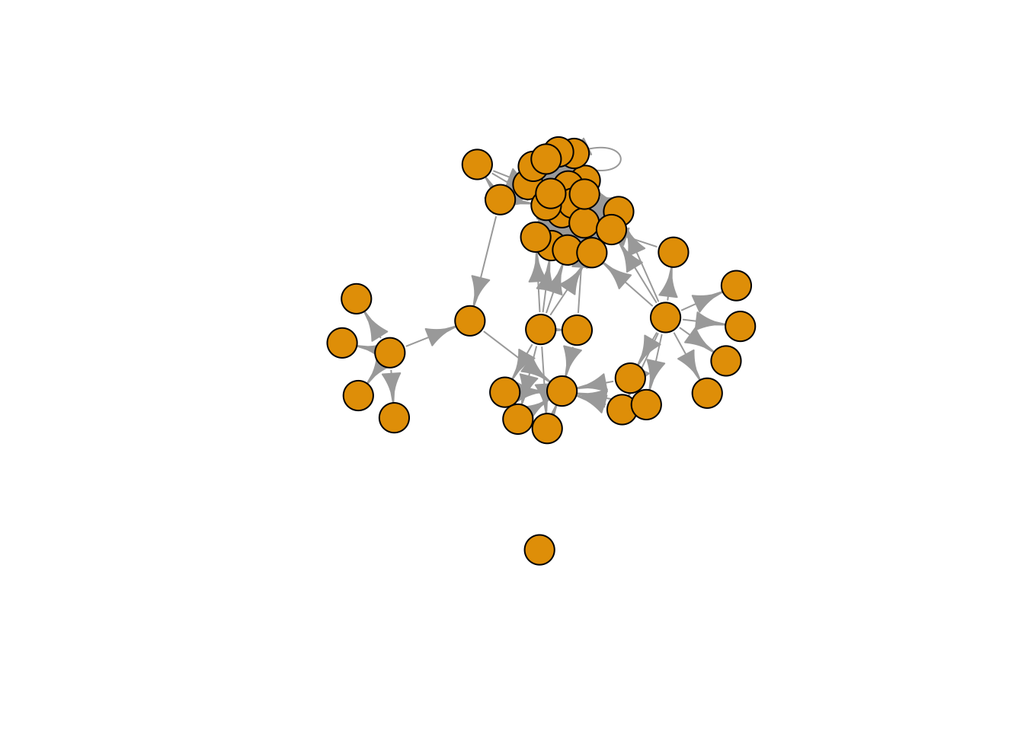

```r
plot(time_nets[[1]], vertex.label="")
```

### 3.2. Making use of node attributes

Color the nodes based on trophic category:

```r
prim.res_names=c("C3.Plants", "C4.Plants",  "Seeds.Fruits","Insects", "Fish" )
for(i in 1:length(time_nets)){
  time_colors=vector(length=length(V(time_nets[[i]])))
  time_colors[V(time_nets[[i]])$category=="browser"]="yellow"
  time_colors[V(time_nets[[i]])$category=="grazer"]="blue"
  time_colors[V(time_nets[[i]])$category=="carnivore"]="red"
  time_colors[V(time_nets[[i]])$category=="mixed feeder"]="brown"
  time_colors[V(time_nets[[i]])$category=="omnivore"]="orange"
  time_colors[V(time_nets[[i]])$category=="frugivore_granivore"]="green"
  time_colors[V(time_nets[[i]])$category=="insectivore"]="purple"
  time_colors[match(V(time_nets[[i]])$name, prim.res_names)]="white"
  #time_colors[time_colors=="FALSE"]="white"
  V(time_nets[[i]])$color=time_colors
}
```

Now re-plot it with the node colors:

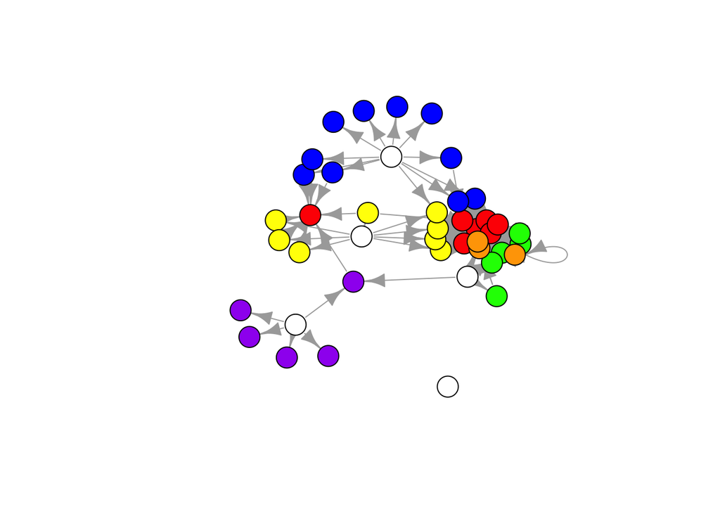

```r
plot(time_nets[[1]], vertex.label="", vertex.color=V(time_nets[[1]])$color)
```

Here is a visualization of all 16 of them.

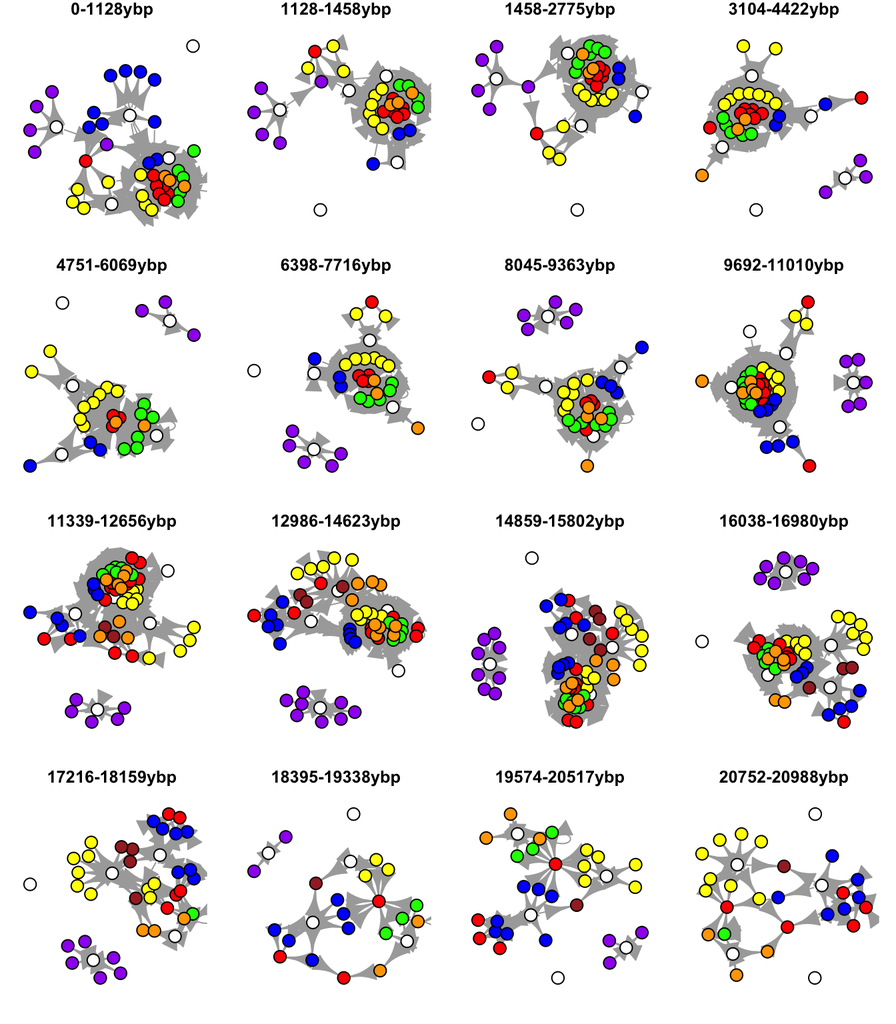

```r
par(mfrow=c(4,4), mar=c(1,1,1,1))
for(i in 1:length(time_nets)){
  plot(time_nets[[i]], vertex.label="", vertex.color=V(time_nets[[i]])$color, main=colnames(interval_dat)[i])
}
```

### 3.3. Calculate foodweb modularity

Based on the foodweb networks we created above, we can measure aspects of the system structure, such as modularity–i.e., the degree to which nodes are clustered together into discrete modules or compartments.

There are many algorithms to calculate modularity that take different approaches to the computational problem of finding partitions in the network. Many of them are not suited for directed networks (i.e., networks in which relationships are asymmetric–as foodwebs are). Here, we will use one relatively simple method that can handle directed networks: *Community Detection based on Edge Betweenness*. This method is described in one of the earliest papers on modularity, by Newman & Girvan (2004).

```r
time_mods=vector(length=length(time_nets))
for(i in 1:length(time_nets)){
  time_mods[i]=modularity(cluster_edge_betweenness(time_nets[[i]], directed=T))
}
```

We can plot the change in foodweb modularity across time–Note that here, the time is plotted in reverse order, with most recent interval on the left. This is just because of the way that the time interval data was organized. We will fix this later. But this just illustrates that something is changing across time.

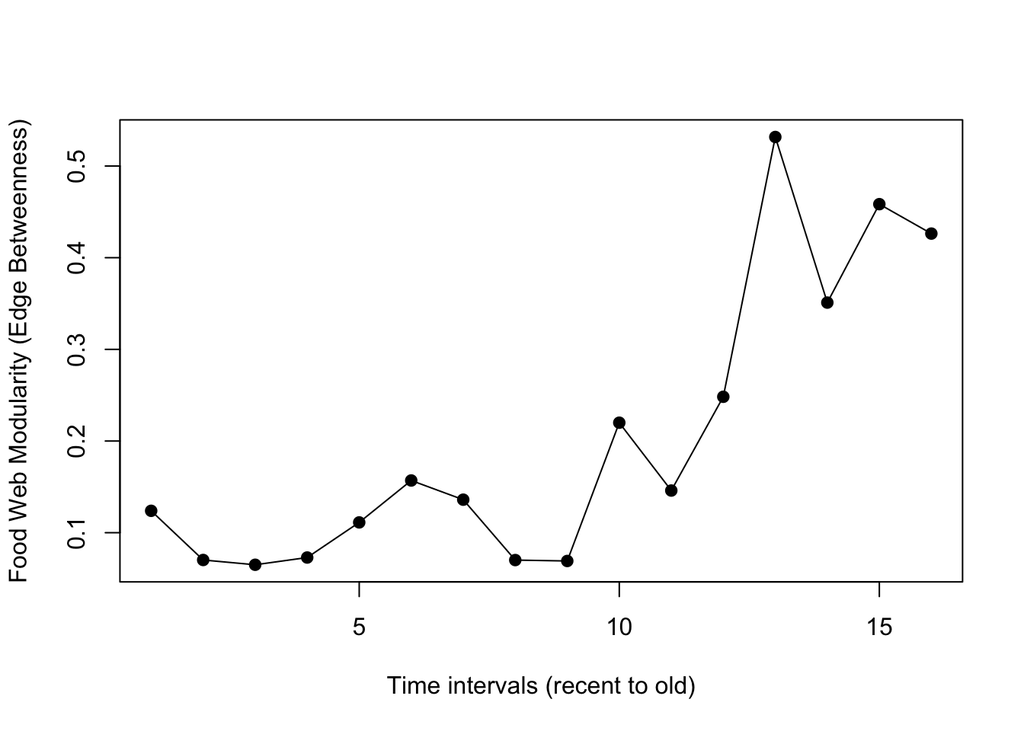

```r
plot(time_mods, type="o", pch=19, xlab="Time intervals (recent to old)", ylab="Food Web Modularity (Edge Betweenness)")
```

## 4. Bipartite Networks

### 4.1. Analyzing bipartite consumer-resource networks

What we did above was to create a directed network from the foodweb matrices. However, there is another type of network–called a “bipartite network”–that is often used in ecological network studies.

Bipartite networks consist of two types of nodes, and edges only connect nodes of different types. This works well for mutualism networks–for example in plant-pollinator networks, plants only interact directly with pollinators and vice versa.

```r
##make into bipartite network

interval_dat_list=list()
for(i in 1:length(time.list)){
  interval_dat_list[[i]]=data.frame(spp=time.list[[i]]) %>% left_join(., spp_attrs, by=c("spp"="Binomial"))
}
```

### 4.3. Build Bipartite Network

In making the bipartite network, there is one interesting question: should omnivores be categorized as “consumer” (i.e., predator) or “resource”. Omnivores include things like field mice (Peromyscus spp), which should probably be “resource”, as well as bears (Ursus spp.), which should probably be “consumer”.

After discussing it a bit, we decided that a way to do this is to have an additional criterion of a “predator/prey ratio” in which we divide the number of predators a species has by the number of prey items it eats. If an omnivore has no or few predators relative to the number of prey items (e.g., bears), then they should be classified as “consumer”. But an omnivore that gets eaten by a lot of predators relative to the number of things it eats (e.g., mice) should be classified as “resource”. For simplicity, we use the threshold of 1–i.e., if predator/prey ratio < 1, it is classified as “consumer” and if it is >=1, it is classified as “resource”.

Here, we are setting this up by calculating the predator/prey ratio from the global matrix. Then, we add this to the attributes list for the data from each interval.

```r
pred.prey.ratio=rowSums(mat)/colSums(mat)

spp_attrs$pred.prey.ratio=pred.prey.ratio[match(spp_attrs$Binomial, names(pred.prey.ratio))]

for(i in 1:length(interval_dat_list)){
interval_dat_list[[i]]$pred.prey.ratio=spp_attrs$pred.prey.ratio[match(interval_dat_list[[i]]$spp, spp_attrs$Binomial)]
}
```

*This is a code to check that the predator/prey ratio thing makes sense. But don’t have to run it.

```r
lapply(interval_dat_list, function(x) table(x$Trophic_Category, x$pred.prey.ratio))
```

Here, we assign ominvores that have low pred/prey ratio (i.e., have few predators and more prey) as “consumer”

```r
bipart.mats=list()
spp_counts=vector()
for(k in 1:length(time.list)){
consumer.rows=which(interval_dat_list[[k]]$Trophic_Category=="omnivore"&interval_dat_list[[k]]$pred.prey.ratio<1|interval_dat_list[[k]]$Trophic_Category=="carnivore"|interval_dat_list[[k]]$Trophic_Category=="insectivore")

resource.rows=which(interval_dat_list[[k]]$Trophic_Category=="omnivore"&(interval_dat_list[[k]]$pred.prey.ratio<1)==FALSE | interval_dat_list[[k]]$Trophic_Category=="browser"|interval_dat_list[[k]]$Trophic_Category=="grazer"|interval_dat_list[[k]]$Trophic_Category=="mixed feeder"|interval_dat_list[[k]]$Trophic_Category=="frugivore_granivore")

consumer.spp=interval_dat_list[[k]]$spp[consumer.rows]
resource.spp=interval_dat_list[[k]]$spp[resource.rows]
bipart.mats[[k]]=time.mats[[k]][match(resource.spp, rownames(time.mats[[k]])), match(consumer.spp, rownames(time.mats[[k]]))]
spp_counts[k]=length(consumer.spp)+length(resource.spp)
}
```

Show the bipartite network for the time interval 1.

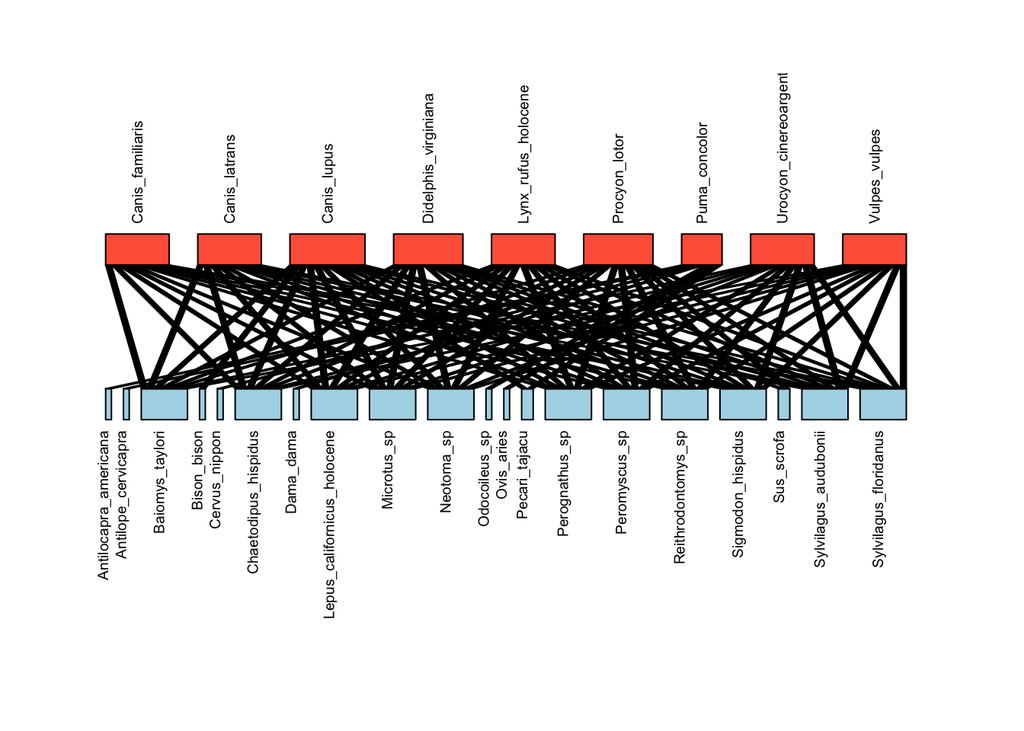

```r
plotweb(bipart.mats[[1]], method="normal",ybig=0.1, arrow="no", col.interaction="black", col.high="tomato", col.low="lightblue",labsize=1,  adj.low=c(1,0), adj.high=c(0,0.5), text.rot = 90, y.lim=c(-1,2.5))
```

## 5. Calculate NOS

Now, we will use the bipartite network to calculate the *Node Overlap and Segregation* index (Strona & Veech 2015). This index measures how much overlap in ‘neighbors’ there are between any pair of nodes, and then compares that to the random expectation.

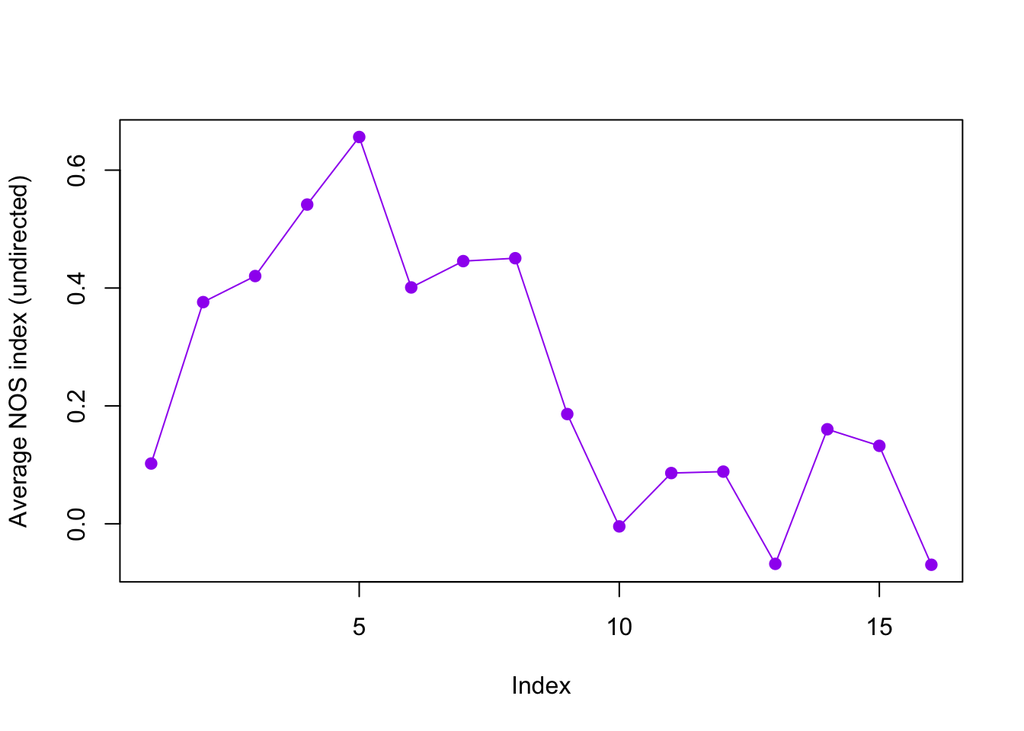

```r
N_bar=sapply(bipart.mats, function(x) NOS(x)$Nbar)
plot(N_bar, type="o", pch=19, col="purple", ylab="Average NOS index (undirected)")
```

### 5.1. Building a dataset and plotting it all together

Extract the beginning and end of the time intervals. *Add a negative sign so that we can orient the plots correctly from the past to present.*

```r
interval.cat=colnames(interval_dat) #the column names from the data set
interval.start=-as.numeric(str_sub(interval.cat, 1, str_locate(interval.cat, "-")[,1]-1)) #get the start of the interval
interval.end=-as.numeric(str_sub(interval.cat, str_locate(interval.cat, "-")[,1]+1, str_length(interval.cat)-3)) # get the end of the interval
```

```r
sum.data=data.frame(interval.name=interval.cat, interval.start=interval.start, interval.end=interval.end, spp.richness=sapply(time.list, length), web.modularity=time_mods, NOS=N_bar, connectance=sapply(bipart.mats, function(x) networklevel(x, index="connectance")), int_diversity=sapply(bipart.mats, function(x) networklevel(x, index="Shannon diversity"))) %>%
  mutate(interval.mid=(interval.start+interval.end)/2)

head(sum.data)
```

```
##              interval.name interval.start interval.end spp.richness
## 0-1128ybp        0-1128ybp              0        -1128           43
## 1128-1458ybp  1128-1458ybp          -1128        -1458           36
## 1458-2775ybp  1458-2775ybp          -1458        -2775           38
## 3104-4422ybp  3104-4422ybp          -3104        -4422           36
## 4751-6069ybp  4751-6069ybp          -4751        -6069           31
## 6398-7716ybp  6398-7716ybp          -6398        -7716           34
##              web.modularity       NOS connectance int_diversity interval.mid
## 0-1128ybp        0.12386667 0.1022482   0.5500000      4.595120       -564.0
## 1128-1458ybp     0.07022940 0.3761013   0.7124183      4.691348      -1293.0
## 1458-2775ybp     0.06501146 0.4203244   0.7309942      4.828314      -2116.5
## 3104-4422ybp     0.07290906 0.5416280   0.7916667      4.736198      -3763.0
## 4751-6069ybp     0.11121962 0.6562500   1.0000000      4.158883      -5410.0
## 6398-7716ybp     0.15695694 0.4009901   0.7156863      4.290459      -7057.0
```

NOS is negatively correlated with modularity

```r
cor.test(sum.data$web.modularity, sum.data$NOS,method="spearman")
```

```
##
##  Spearman's rank correlation rho
##
## data:  sum.data$web.modularity and sum.data$NOS
## S = 1146, p-value = 0.004431
## alternative hypothesis: true rho is not equal to 0
## sample estimates:
##        rho
## -0.6852941
```

Modularity is not correlated with species richness

```r
cor.test(sum.data$spp.richness, sum.data$web.modularity,method="spearman")
```

```
##
##  Spearman's rank correlation rho
##
## data:  sum.data$spp.richness and sum.data$web.modularity
## S = 848.25, p-value = 0.3555
## alternative hypothesis: true rho is not equal to 0
## sample estimates:
##        rho
## -0.2474229
```

### 5.2. Plot the modularity and NOS data across time

This will produce the overlay plot of the modularity and NOS index across time. I’ve added some shading to aid the visuals. The time intervals as designated in the dataset are shaded in gray. The pale yellow interval is the time interval that corresponds to the beginning of the Holocene (I think). The dots are set at the midpoint of each time interval.

We’ll use the “plasma” palette from the **viridisLite** package.

```r
my.palette=plasma(2, begin=0, end=0.8)
```

Plot the change in NOS across time. *Note that we want to plot the x-axis correctly so that we start with the oldest time interval to the left, and move forward in time to the right, while the x-axis label is in “years before present” (i.e., numbers get larger to the left). To do this, we add a negative sign to the time interval (to make them positive numbers), but reverse the x-axis using the ggplot function `scale_x_reverse()`.

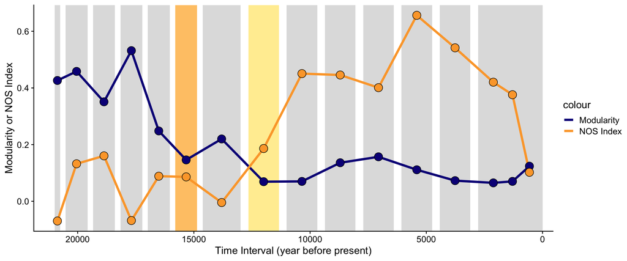

```r
mod.nos.plot=ggplot(data=sum.data, aes(x=-interval.mid)) +
  #geom_vline(xintercept = interval.start, color="gray") +
  geom_rect(xmin=interval.start, xmax=interval.end, ymin=-0.5, ymax=Inf, fill="gray", alpha=0.5) +
  geom_rect(xmin=interval.start[9], xmax=interval.end[9], ymin=-0.5, ymax=Inf, fill="#ffeda0", alpha=0.5) +
    geom_rect(xmin=interval.start[11], xmax=interval.end[11], ymin=-0.5, ymax=Inf, fill="#ffc675", alpha=0.5) +
  geom_line(aes(y=web.modularity, color="Modularity"), lwd=1.5) +
  geom_line(aes(y=NOS, color="NOS Index"), lwd=1.5) +
  scale_color_manual(values=my.palette) +
  geom_point(aes(y=web.modularity), size=5, shape=21, fill=my.palette[1]) +
  geom_point(aes(y=NOS), size=5, shape=21, fill=my.palette[2]) +
  theme_cowplot() +
  scale_x_reverse()+
  xlab("Time Interval (year before present)") +
  ylab("Modularity or NOS Index")

mod.nos.plot
```

Make the same plot for **connectance**

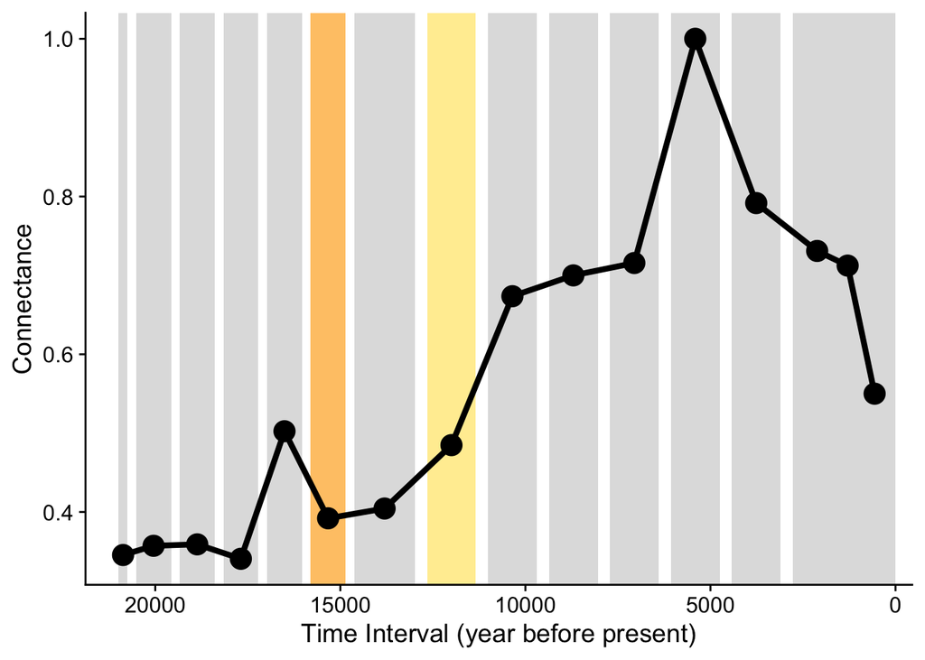

```r
connectance.plot=ggplot(data=sum.data, aes(x=-interval.mid)) +
  #geom_vline(xintercept = interval.start, color="gray") +
  geom_rect(xmin=interval.start, xmax=interval.end, ymin=-0.5, ymax=Inf, fill="gray", alpha=0.5) +
  geom_rect(xmin=interval.start[9], xmax=interval.end[9], ymin=-0.5, ymax=Inf, fill="#ffeda0", alpha=0.5) +
    geom_rect(xmin=interval.start[11], xmax=interval.end[11], ymin=-0.5, ymax=Inf, fill="#ffc675", alpha=0.5) +
  geom_line(aes(y=connectance), lwd=1.5) +
  geom_point(aes(y=connectance), size=5) +
  theme_cowplot() +
  scale_x_reverse()+
  xlab("Time Interval (year before present)") +
  ylab("Connectance")

connectance.plot
```

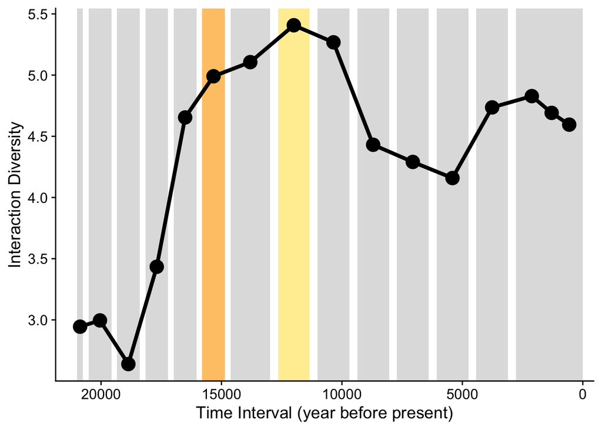

```r
int_diversity.plot=ggplot(data=sum.data, aes(x=-interval.mid)) +
  #geom_vline(xintercept = interval.start, color="gray") +
  geom_rect(xmin=interval.start, xmax=interval.end, ymin=-0.5, ymax=Inf, fill="gray", alpha=0.5) +
  geom_rect(xmin=interval.start[9], xmax=interval.end[9], ymin=-0.5, ymax=Inf, fill="#ffeda0", alpha=0.5) +
    geom_rect(xmin=interval.start[11], xmax=interval.end[11], ymin=-0.5, ymax=Inf, fill="#ffc675", alpha=0.5) +
  geom_line(aes(y=int_diversity), lwd=1.5) +
  geom_point(aes(y=int_diversity), size=5) +
  theme_cowplot() +
  scale_x_reverse()+
  xlab("Time Interval (year before present)") +
  ylab("Interaction Diversity")

int_diversity.plot
```

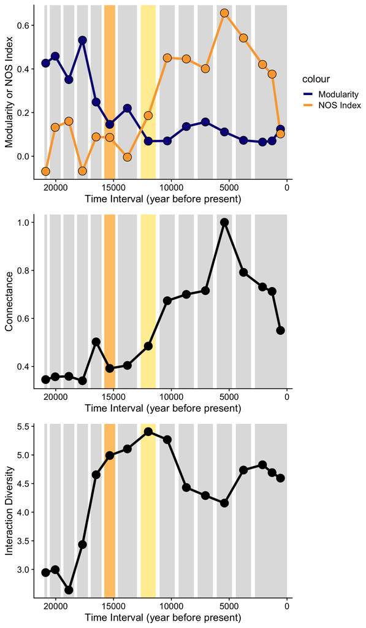

```r
plot_grid(mod.nos.plot, connectance.plot, int_diversity.plot, nrow=3, align="v")
```

## 6. Null model testing of NOS

We had started by trying out the standard null model functions in the `ecosim` package, but we realized that those were not going to work for our purposes. One of the main reasons we were unsatisfied with this is because those procedures simply shuffle the edges around the existing predators and prey within each time interval. However, for our questions, what we are actually interested in is, *what would the foodweb structure look like if we had a different set of predators and prey?*. That is, what if different sets of species had gone extinct or had come in to that system during that time?

So to test that hypothesis, we are going to use a custom null model by random resampling of predators and prey from the global list. That is:

1. For each time interval, figure out number of predators and prey
2. In each permutation, randomly pull that number of predators and prey from the set of all predators and prey.
3. Calculate NOS
4. Repeat x10,000
5. Compare distribution of NOS values from the permutations against the observed NOS value.
6. Repeat for all time intervals.

### 6.1. Null model using random sampling of predators and prey species

Get the list of species and categorize them into consumer vs. resource

First, take the number of predators and prey for each time interval. We can do that from each bipart.mats

```r
prey.n=sapply(bipart.mats, dim)[1,]
pred.n=sapply(bipart.mats, dim)[2,]
```

Get the global set of species that were seen at Halls Cave in ANY time interval:

```r
all.spp.in.HC=data.frame(spps=unique(unlist(sapply(time.mats, rownames))))
```

```r
all.consumers=left_join(all.spp.in.HC, spp_attrs, by=join_by("spps"=="Binomial")) %>% filter(Trophic_Category=="omnivore"&pred.prey.ratio<1|Trophic_Category=="carnivore"|Trophic_Category=="insectivore") %>%
  pull(spps)

all.resources=left_join(all.spp.in.HC, spp_attrs, by=join_by("spps"=="Binomial")) %>% filter(Trophic_Category=="omnivore"&(pred.prey.ratio<1)==FALSE|Trophic_Category=="browser"|Trophic_Category=="grazer"|Trophic_Category=="mixed feeder"|Trophic_Category=="frugivore_granivore") %>%
  pull(spps)
```

### 6.2. Building the null model framework:

First, we try making a single randomized network and calculate Nbar

```r
null.consumers1=sample(all.consumers, size=pred.n[1])
null.resources1=sample(all.resources, size=prey.n[1])
nullmat1=mat[match(null.resources1,rownames(mat)), match(null.consumers1,colnames(mat))]
NOS(nullmat1)$Nbar
```

```
## [1] -0.0812754
```

Get null distribution of Nbar values for all time intervals with x10,000 permutations.

```r
null.nos=list()

for (j in 1:length(pred.n)){
times=10000
Nbars=vector(length=times)
for(i in 1:times){
  null.consumers1=sample(all.consumers, size=pred.n[j])
null.resources1=sample(all.resources, size=prey.n[j])
nullmat1=mat[match(null.resources1,rownames(mat)), match(null.consumers1,colnames(mat))]
Nbars[i]=NOS(nullmat1)$Nbar
}
null.nos[[j]]=Nbars
}
```

To save time, don’t run the code above and just import a previous run of this model:

```r
load("Supplemental Data/null_nos.rdata")
```

### 6.3. Extract the means and 95% confidence intervals of the null model NOS index for each time interval.

Use 95% confidence interval instead of using the standard error of the mean

Calculate mean and confidence interval from null distribution of NOS values

```r
NOS_mean=sapply(null.nos, mean)
NOS_ci=sapply(null.nos, function(x) quantile(x, probs=c(0.025, 0.975)))
```

Add the mean and lower and upper confidence to the sum.datas

```r
sum.data$NOS.mean.null=NOS_mean
sum.data$NOS.lower_ci=unlist(NOS_ci[1,])
sum.data$NOS.upper_ci=unlist(NOS_ci[2,])
```

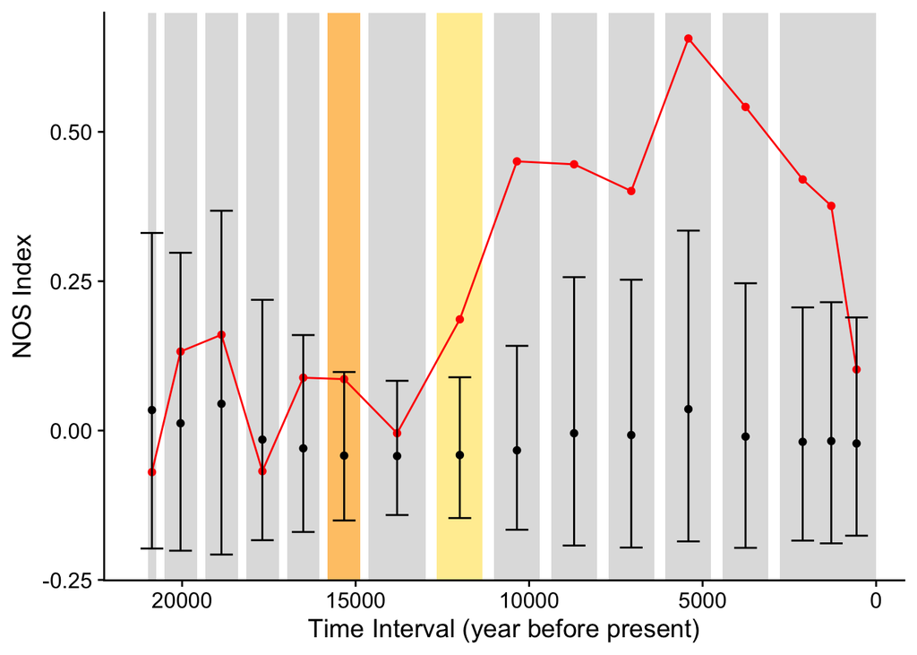

```r
ggplot(data=sum.data, aes(x=-interval.mid)) +
  #geom_vline(xintercept = interval.start, color="gray") +
 geom_rect(xmin=interval.start, xmax=interval.end, ymin=-0.25, ymax=Inf, fill="gray", alpha=0.5) +
 geom_rect(xmin=interval.start[9], xmax=interval.end[9], ymin=-0.25, ymax=Inf, fill="#ffeda0", alpha=0.5) +
    geom_rect(xmin=interval.start[11], xmax=interval.end[11], ymin=-0.5, ymax=Inf, fill="#ffc675", alpha=0.5) +
  geom_point(aes(y=NOS), color="red") +
  geom_line(aes(y=NOS, color="NOS Index")) +
  geom_point(aes(y=NOS.mean.null, color="Expected NOS Index"), color="black") +
  #geom_line(aes(y=NOS.mean.null, color="Expected NOS Index")) +
  geom_errorbar(aes(ymin=NOS.lower_ci, ymax=NOS.upper_ci), color="black") +
  scale_color_manual(values=c("red")) +
  theme_cowplot() +
  theme(legend.position="none") +
  scale_x_reverse() +
  labs(color = "Value") +
  xlab("Time Interval (year before present)") +
  ylab("NOS Index")
```

### 6.4. Calculate P-values for null model test

To calculate p-values, we need to first get the observed NOS values:

```r
sum.data$NOS
```

```
##  [1]  0.10224823  0.37610132  0.42032443  0.54162801  0.65625000  0.40099010
##  [7]  0.44565217  0.45058275  0.18619531 -0.00444171  0.08608389  0.08851707
## [13] -0.06796117  0.16037736  0.13227513 -0.06952124
```

So, for time interval 1 (the closest to present):

```r
(length(which(null.nos[[1]]>sum.data$NOS[1]))/10000)*2
```

```
## [1] 0.2026
```

We can use a for loop to do this for all time intervals:

```r
p.list=list()
for(i in 1:nrow(sum.data)){
  p.list[[i]]=(length(which(null.nos[[i]]>sum.data$NOS[i]))/10000)
}
unlist(p.list)
```

```
##  [1] 0.1013 0.0015 0.0004 0.0001 0.0001 0.0034 0.0007 0.0000 0.0009 0.2350
## [11] 0.0351 0.0894 0.6648 0.2048 0.1671 0.7920
```

So, *the food web is significantly less modular (higher NOS, or node overlap) than expected by chance for Time Intervals 2-9 (all of Holocene, excluding the most recent time interval)*

Add this to the sum.data

```r
sum.data$P.value=unlist(p.list)
```

## 7. Climate Over Time

### 7.1. Ensuring column names are read as characters

```r
# The column names are numbers and aren't read correctly, convert the names into "ASCII". This will fix the weird symbols in front of the names
names(interval_dat) <- iconv(colnames(interval_dat), to = "ASCII", sub = "")
```

### 7.2 Dataframe of Time and Climate Data

```r
# Create a dataframe of Time and Climate ####
spp_count=sapply(time.list, length)
time.dat = data.frame(Interval_ID=1:16,
           interval=names(interval_dat),
           interval.start=interval.start,
           interval.end=interval.end,
           TM = time_mods,
           SpC = spp_count, # Making Species counts to add as a column
           Tavg = climate_dat$Calculated_Average_Temp,
           Tmax = climate_dat$CCSM_Max_Temp_C,
           Tmax_SD = climate_dat$CCSM_Max_Temp_SD,
           Tmin = climate_dat$CCSM_Min_Temp_C,
           Tmin_SD = climate_dat$CCSM_Min_Temp_SD,
           Pr = climate_dat$CCSM_Precip_mm,
           PrCv = climate_dat$CCSM_Precip_CV) %>%
  mutate(interval.mid=(interval.start+interval.end)/2)
```

Variables may be auto correlated with Time. To account for any temporal auto correlations, we need to look at the difference between time intervals (ex: Time Interval 1 - Time Interval 2…)

Using the lead() function, we can subtract to get the difference between intervals. Therefore, calculating the change that occurs with a change in modularity over time.

Note: This ultimately removes a time bin.

### 7.3. Dataframe of the Change

```r
time.dat.change = data.frame(Interval_ID=1:16,
                      interval=names(interval_dat),
                      interval.start=interval.start,
                      interval.end=interval.end,
                      TM.change = time_mods-lead(time_mods),
                      Tavg.change = climate_dat$Calculated_Average_Temp-lead(climate_dat$Calculated_Average_Temp),
                      SpC.change = spp_count-lead(spp_count),
                      Pr.change = climate_dat$CCSM_Precip_mm-lead(climate_dat$CCSM_Precip_mm),
                      Tmax.change = climate_dat$CCSM_Max_Temp_C-lead(climate_dat$CCSM_Max_Temp_C),
                      Tmax_SD.change = climate_dat$CCSM_Max_Temp_SD-lead(climate_dat$CCSM_Max_Temp_SD),
                      Tmin.change = climate_dat$CCSM_Min_Temp_C-lead(climate_dat$CCSM_Min_Temp_C),
                      Tmin_SD.change = climate_dat$CCSM_Min_Temp_SD-lead(climate_dat$CCSM_Min_Temp_SD),
                      PrCv.change = climate_dat$CCSM_Precip_CV-lead(climate_dat$CCSM_Precip_CV)) %>%
  mutate(interval.mid=(interval.start+interval.end)/2)
```

### 7.4. Plotting Climate and Modularity

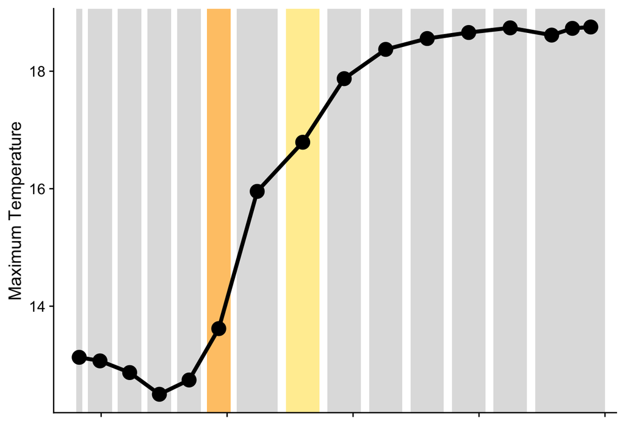

```r
#just raw temperature across time

temp.plot = ggplot(data=time.dat, aes(x=-interval.mid)) +
  geom_rect(xmin=interval.start, xmax=interval.end, ymin=-0.3, ymax=Inf, fill="gray", alpha=0.5) +
  geom_rect(xmin=interval.start[9], xmax=interval.end[9], ymin=-0.3, ymax=Inf, fill="#ffeda0", alpha=0.5) +
      geom_rect(xmin=interval.start[11], xmax=interval.end[11], ymin=-0.3, ymax=Inf, fill="#ffc675", alpha=0.5) +
  geom_point(aes(y=Tavg), color="black", size=5) +
  geom_line(aes(y=Tavg), lwd=1.5) +
  scale_color_manual(values=c("black")) +
  theme_cowplot() +
  scale_x_reverse()+
  xlab("Time Interval (year before present)") +
  ylab("Maximum Temperature")+
  theme(axis.text.x=element_blank()) +
  xlab("")

temp.plot
```

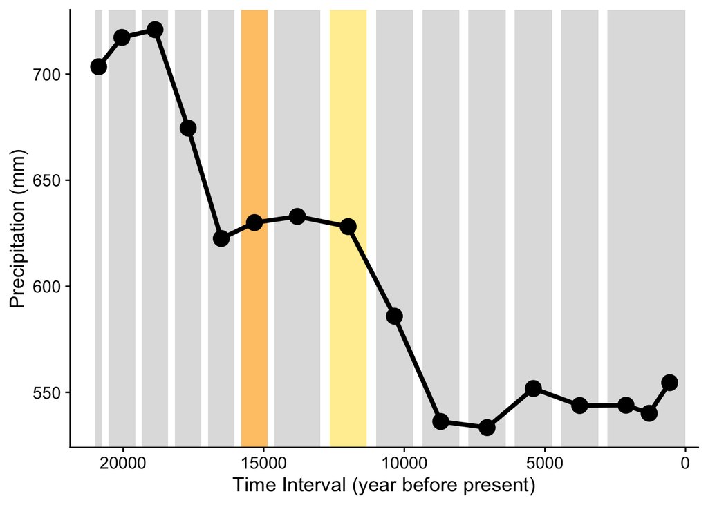

```r
# Plotting precipitation  over time

precip.plot = ggplot(data=time.dat, aes(x=-interval.mid)) +
  geom_rect(xmin=interval.start, xmax=interval.end, ymin=-60, ymax=Inf, fill="gray", alpha=0.5) +
  geom_rect(xmin=interval.start[9], xmax=interval.end[9], ymin=-60, ymax=Inf, fill="#ffeda0", alpha=0.5) +
      geom_rect(xmin=interval.start[11], xmax=interval.end[11], ymin=-60, ymax=Inf, fill="#ffc675", alpha=0.5) +
  geom_point(aes(y=Pr), color="black", size=5) +
  geom_line(aes(y=Pr), lwd=1.5) +
  scale_color_manual(values=c("black")) +
  theme_cowplot() +
  scale_x_reverse() +
  xlab("Time Interval (year before present)") +
  ylab("Precipitation (mm)")

precip.plot
```

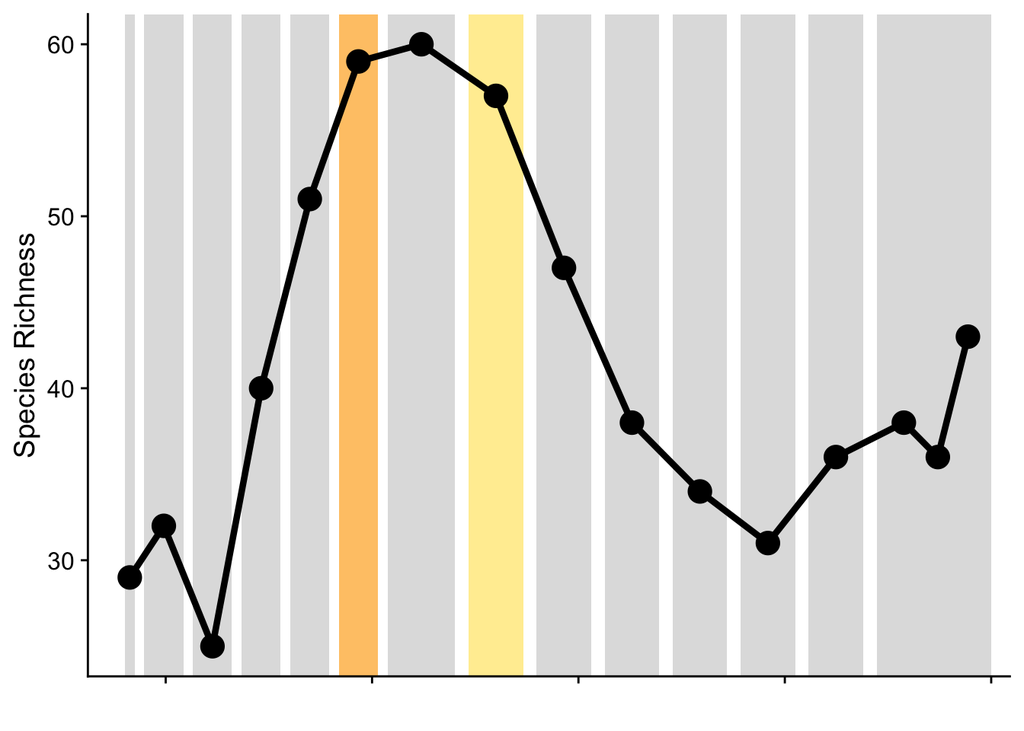

```r
# Plotting the raw species richness (spc) over time

spcraw.plot = ggplot(data=time.dat, aes(x=-interval.mid)) +
  geom_rect(xmin=interval.start, xmax=interval.end, ymin=-25, ymax=Inf, fill="gray", alpha=0.5) +
  geom_rect(xmin=interval.start[9], xmax=interval.end[9], ymin=-25, ymax=Inf, fill="#ffeda0", alpha=0.5) +
      geom_rect(xmin=interval.start[11], xmax=interval.end[11], ymin=-25, ymax=Inf, fill="#ffc675", alpha=0.5) +
  geom_point(aes(y=SpC), color="black", size=5) +
  geom_line(aes(y=SpC), lwd=1.5) +
  scale_color_manual(values=c("black")) +
  theme_cowplot() +
  scale_x_reverse() +
  xlab("Time Interval (year before present)") +
  ylab("Species Richness") +
  theme(axis.text.x=element_blank()) +
  xlab("")

spcraw.plot
```

## Figure 3:

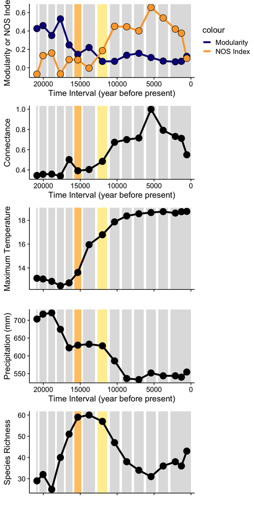

```r
plot_grid(mod.nos.plot, connectance.plot, temp.plot, precip.plot, spcraw.plot, nrow=5, align="v")
```

## 8. Spearman-Rank Correlations

Spearman-Rank Correlation here is a non-parametric statistical test used to understand how well correlated a relationship between two variables. In this case, we will be testing the relationship between the change in temperature, precipitation, and species richness to the change we see in modularity over time.

Plots.

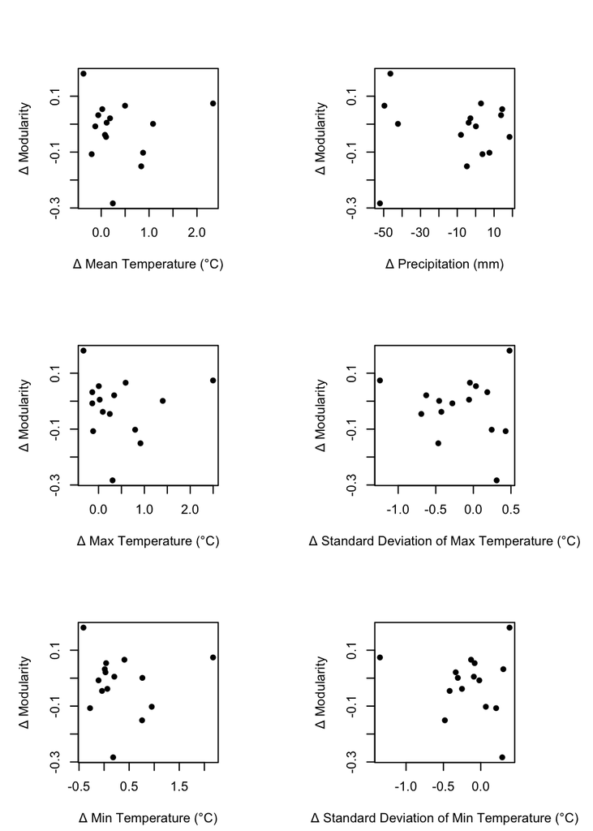

```r
par(mfrow=c(3,2), mar=c(1,5,1,5), pty = "s")

plot(time.dat.change$Tavg.change, time.dat.change$TM.change, type="p", col="black", pch=16, xlab = "Δ Mean Temperature (°C)", ylab = "Δ Modularity")

plot(time.dat.change$Pr.change, time.dat.change$TM.change, type="p", col="black", pch=16, xlab = "Δ Precipitation (mm)", ylab = "Δ Modularity")

plot(time.dat.change$Tmax.change, time.dat.change$TM.change, type="p", col="black", pch=16, xlab = "Δ Max Temperature (°C)", ylab = "Δ Modularity")

plot(time.dat.change$Tmax_SD.change, time.dat.change$TM.change, type="p", col="black", pch=16, xlab = "Δ Standard Deviation of Max Temperature (°C)", ylab = "Δ Modularity")

plot(time.dat.change$Tmin.change, time.dat.change$TM.change, type="p", col="black", pch=16, xlab = "Δ Min Temperature (°C)", ylab = "Δ Modularity")

plot(time.dat.change$Tmin_SD.change, time.dat.change$TM.change, type="p", col="black", pch=16, xlab = "Δ Standard Deviation of Min Temperature (°C)", ylab = "Δ Modularity")
```

```r
par(mfrow=c(1,1), pty = "s")
```

Plot the species change vs. modularity change (Figure 4)

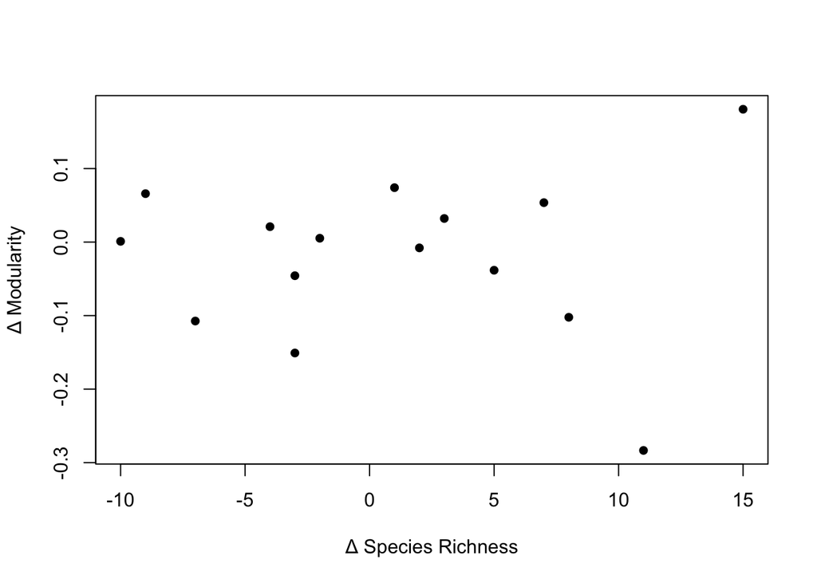

```r
plot(time.dat.change$SpC.change, time.dat.change$TM.change, type="p", col="black", pch=16, xlab = "Δ Species Richness", ylab = "Δ Modularity")
```

Cleaner versions with ggplot

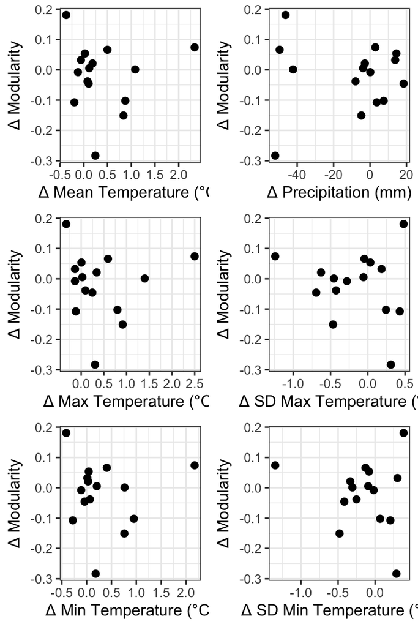

```r
p1=ggplot(time.dat.change, aes(x=Tavg.change, y=TM.change))+
  geom_point(size=2) +
  theme_bw() +
  ylab("Δ Modularity") +
  xlab("Δ Mean Temperature (°C)")


p2=ggplot(time.dat.change, aes(x=Pr.change, y=TM.change))+
  geom_point(size=2) +
  theme_bw() +
  ylab("Δ Modularity") +
  xlab("Δ Precipitation (mm)")

p3=ggplot(time.dat.change, aes(x=Tmax.change, y=TM.change))+
  geom_point(size=2) +
  theme_bw() +
  ylab("Δ Modularity") +
  xlab("Δ Max Temperature (°C)")

p4=ggplot(time.dat.change, aes(x=Tmax_SD.change, y=TM.change))+
  geom_point(size=2) +
  theme_bw() +
  ylab("Δ Modularity") +
  xlab("Δ SD Max Temperature (°C)")

p5=ggplot(time.dat.change, aes(x=Tmin.change, y=TM.change))+
  geom_point(size=2) +
  theme_bw() +
  ylab("Δ Modularity") +
  xlab("Δ Min Temperature (°C)")

p6=ggplot(time.dat.change, aes(x=Tmin_SD.change, y=TM.change))+
  geom_point(size=2) +
  theme_bw() +
  ylab("Δ Modularity") +
  xlab("Δ SD Min Temperature (°C)")


plot_grid(p1, p2, p3, p4, p5, p6, ncol=2)
```

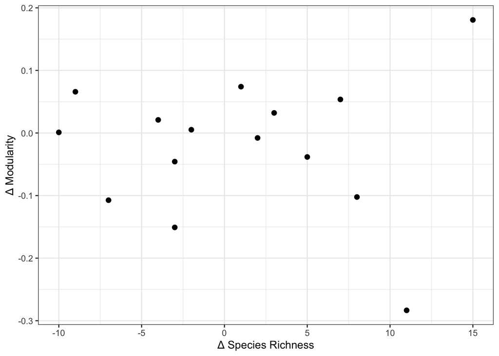

```r
ggplot(time.dat.change, aes(x=SpC.change, y=TM.change))+
  geom_point(size=2) +
  theme_bw() +
  ylab("Δ Modularity") +
  xlab("Δ Species Richness")
```

### 8.1. So, what statistic correlates best with modularity?

Run spearman correlations and arrange results into table.

```r
key_stats <- c("Tavg.change", "Pr.change", "SpC.change", "Tmax.change", "Tmax_SD.change", "Tmin.change", "Tmin_SD.change");
spearman_summaries <- data.frame(stat=as.character(key_stats),rho=as.numeric(rep(0,length(key_stats))),pvalue=as.numeric(rep(0,length(key_stats))));
for (ks in 1:length(key_stats)) {
  spearman_test <- cor.test(time.dat.change[,match(key_stats[ks],colnames(time.dat.change))],time.dat.change$TM.change,method="spearman");
spearman_summaries$rho[ks] <- round(spearman_test$estimate,3);
spearman_summaries$pvalue[ks] <- spearman_test$p.value;
if (spearman_summaries$pvalue[ks]>10^-2)  {
  spearman_summaries$pvalue[ks] <- round(spearman_summaries$pvalue[ks],3)
  } else  {
    spearman_summaries$pvalue[ks] <- round(spearman_summaries$pvalue[ks]/(10^floor(log10(spearman_summaries$pvalue[ks]))),2)*(10^floor(log10(spearman_summaries$pvalue[ks])))
  }
}
spearman_summaries$rho2 <- spearman_summaries$rho^2;

spearman_summaries
```

```
##             stat    rho pvalue     rho2
## 1    Tavg.change -0.107  0.705 0.011449
## 2      Pr.change -0.004  0.995 0.000016
## 3     SpC.change  0.038  0.894 0.001444
## 4    Tmax.change -0.150  0.593 0.022500
## 5 Tmax_SD.change -0.054  0.853 0.002916
## 6    Tmin.change -0.054  0.853 0.002916
## 7 Tmin_SD.change  0.007  0.985 0.000049
```

### 9.1. Extra: Spearman Partial Correlations

Partial correlations tests the relationship between two variables while controlling for a third variable. Here, we test the correlation between modularity, temperature, precipitation, and species richness while controlling for each variable. *This method allows us to see if the correlation between the first and third variable is due to the direct correlations between 1 & 2 and 2 & 3*

```r
pcor_1 = pcor.test(na.exclude(time.dat.change$TM.change),na.exclude(time.dat.change$Tavg.change),na.exclude(time.dat.change$Pr.change),method="spearman");

pcor_2 = pcor.test(na.exclude(time.dat.change$TM.change),na.exclude(time.dat.change$Pr.change),na.exclude(time.dat.change$Tavg.change),method="spearman");

pcor_3 = pcor.test(na.exclude(time.dat.change$TM.change),na.exclude(time.dat.change$Tavg.change),na.exclude(time.dat.change$SpC.change),method="spearman");

pcor_4 = pcor.test(na.exclude(time.dat.change$TM.change),na.exclude(time.dat.change$SpC.change),na.exclude(time.dat.change$Tavg.change),method="spearman");

pcor_5 = pcor.test(na.exclude(time.dat.change$TM.change),na.exclude(time.dat.change$Pr.change),na.exclude(time.dat.change$SpC.change),method="spearman");

pcor_6 = pcor.test(na.exclude(time.dat.change$TM.change),na.exclude(time.dat.change$SpC.change),na.exclude(time.dat.change$Pr.change),method="spearman");

pcor_all = data.frame(rbind(pcor_1,pcor_2,pcor_3,pcor_4,pcor_5,pcor_6))

pcor_all$correlation <- c("Mod + Temp - Precip", "Mod + Precip - Temp", "Mod + Temp - Rich", "Mod + Rich - Temp", "Mod + Precip - Rich", 'Mod + Rich - Precip')

pcor_all
```

```
##       estimate   p.value   statistic  n gp   Method         correlation
## 1 -0.110177696 0.7076926 -0.38400459 15  1 spearman Mod + Temp - Precip
## 2 -0.026075632 0.9294924 -0.09035936 15  1 spearman Mod + Precip - Temp
## 3 -0.100570833 0.7322857 -0.35016295 15  1 spearman   Mod + Temp - Rich
## 4  0.005455180 0.9852334  0.01889758 15  1 spearman   Mod + Rich - Temp
## 5 -0.004447856 0.9879599 -0.01540798 15  1 spearman Mod + Precip - Rich
## 6  0.037626907 0.8983827  0.13043580 15  1 spearman Mod + Rich - Precip
```

### 9.2. Multiple Regression

```r
multiple_regressions_all <- summary(lm(time.dat.change$TM.change ~ (time.dat.change$Tavg.change+time.dat.change$Pr.change+time.dat.change$SpC.change+time.dat.change$Tmax.change+time.dat.change$Tmax_SD.change+time.dat.change$Tmin.change+time.dat.change$Tmin_SD.change)));
multiple_regressions_all$r.squared;
```

```
## [1] 0.1091048
```

```r
multiple_regressions_all$adj.r.squared;
```

```
## [1] -0.5590665
```

```r
multiple_regressions_all$coefficients;
```

```
##                                     Estimate  Std. Error     t value  Pr(>|t|)
## (Intercept)                    -0.0154693992 0.047842781 -0.32333821 0.7547293
## time.dat.change$Tavg.change    -0.0422302130 0.583564415 -0.07236598 0.9440872
## time.dat.change$Pr.change      -0.0008109441 0.002081604 -0.38957660 0.7070155
## time.dat.change$SpC.change      0.0011085537 0.006233242  0.17784545 0.8632651
## time.dat.change$Tmax.change    -0.0567578576 0.562729250 -0.10086175 0.9221422
## time.dat.change$Tmax_SD.change  0.0853002837 0.271558744  0.31411356 0.7614698
## time.dat.change$Tmin_SD.change -0.2809948009 0.390957720 -0.71873450 0.4927601
```

```r
multiple_regressions_all$cov.unscaled;
```

```
##                                  (Intercept) time.dat.change$Tavg.change
## (Intercept)                     0.1213147368                  0.21068576
## time.dat.change$Tavg.change     0.2106857573                 18.04921549
## time.dat.change$Pr.change       0.0004255909                 -0.03379110
## time.dat.change$SpC.change     -0.0047992497                 -0.09158871
## time.dat.change$Tmax.change    -0.3024866826                -17.05286010
## time.dat.change$Tmax_SD.change  0.1617062863                 -3.28968298
## time.dat.change$Tmin_SD.change -0.2328890091                  2.73108991
##                                time.dat.change$Pr.change
## (Intercept)                                 0.0004255909
## time.dat.change$Tavg.change                -0.0337910969
## time.dat.change$Pr.change                   0.0002296555
## time.dat.change$SpC.change                  0.0001554878
## time.dat.change$Tmax.change                 0.0370951641
## time.dat.change$Tmax_SD.change              0.0029518248
## time.dat.change$Tmin_SD.change              0.0081090051
##                                time.dat.change$SpC.change
## (Intercept)                                 -0.0047992497
## time.dat.change$Tavg.change                 -0.0915887096
## time.dat.change$Pr.change                    0.0001554878
## time.dat.change$SpC.change                   0.0020592482
## time.dat.change$Tmax.change                  0.0879680041
## time.dat.change$Tmax_SD.change               0.0037438031
## time.dat.change$Tmin_SD.change              -0.0084920624
##                                time.dat.change$Tmax.change
## (Intercept)                                    -0.30248668
## time.dat.change$Tavg.change                   -17.05286010
## time.dat.change$Pr.change                       0.03709516
## time.dat.change$SpC.change                      0.08796800
## time.dat.change$Tmax.change                    16.78339076
## time.dat.change$Tmax_SD.change                  2.42080882
## time.dat.change$Tmin_SD.change                 -0.83674220
##                                time.dat.change$Tmax_SD.change
## (Intercept)                                       0.161706286
## time.dat.change$Tavg.change                      -3.289682978
## time.dat.change$Pr.change                         0.002951825
## time.dat.change$SpC.change                        0.003743803
## time.dat.change$Tmax.change                       2.420808817
## time.dat.change$Tmax_SD.change                    3.908483734
## time.dat.change$Tmin_SD.change                   -4.925365775
##                                time.dat.change$Tmin_SD.change
## (Intercept)                                      -0.232889009
## time.dat.change$Tavg.change                       2.731089912
## time.dat.change$Pr.change                         0.008109005
## time.dat.change$SpC.change                       -0.008492062
## time.dat.change$Tmax.change                      -0.836742201
## time.dat.change$Tmax_SD.change                   -4.925365775
## time.dat.change$Tmin_SD.change                    8.101031372
```

```r
multiple_regressions_all
```

```
##
## Call:
## lm(formula = time.dat.change$TM.change ~ (time.dat.change$Tavg.change +
##     time.dat.change$Pr.change + time.dat.change$SpC.change +
##     time.dat.change$Tmax.change + time.dat.change$Tmax_SD.change +
##     time.dat.change$Tmin.change + time.dat.change$Tmin_SD.change))
##
## Residuals:
##      Min       1Q   Median       3Q      Max
## -0.24024 -0.05611  0.01092  0.06448  0.17486
##
## Coefficients: (1 not defined because of singularities)
##                                  Estimate Std. Error t value Pr(>|t|)
## (Intercept)                    -0.0154694  0.0478428  -0.323    0.755
## time.dat.change$Tavg.change    -0.0422302  0.5835644  -0.072    0.944
## time.dat.change$Pr.change      -0.0008109  0.0020816  -0.390    0.707
## time.dat.change$SpC.change      0.0011086  0.0062332   0.178    0.863
## time.dat.change$Tmax.change    -0.0567579  0.5627292  -0.101    0.922
## time.dat.change$Tmax_SD.change  0.0853003  0.2715587   0.314    0.761
## time.dat.change$Tmin.change            NA         NA      NA       NA
## time.dat.change$Tmin_SD.change -0.2809948  0.3909577  -0.719    0.493
##
## Residual standard error: 0.1374 on 8 degrees of freedom
##   (1 observation deleted due to missingness)
## Multiple R-squared:  0.1091, Adjusted R-squared:  -0.5591
## F-statistic: 0.1633 on 6 and 8 DF,  p-value: 0.9799
```

## Supplemental Analyses

### Tabulate trophic categories

```r
categories=unique(spp_attrs$Trophic_Category)
for(i in 1:length(interval_dat_list)){
  interval_dat_list[[i]]$interval=i
}
interval_dat_all=bind_rows(interval_dat_list)
```

```r
troph_props=interval_dat_all %>%
  group_by(interval, Trophic_Category, .drop=FALSE) %>%
  count() %>%
  group_by(interval) %>%
  mutate(prop=n/sum(n)) %>%
  pivot_wider(id_cols=interval, names_from=Trophic_Category, values_from = prop) %>%
  replace(is.na(.), 0)

troph_props
```

```
## # A tibble: 16 × 9
## # Groups:   interval [16]
##    interval browser carnivore frugivore_granivore grazer insectivore omnivore
##       <int>   <dbl>     <dbl>               <dbl>  <dbl>       <dbl>    <dbl>
##  1        1   0.186    0.163               0.116  0.233       0.116    0.0698
##  2        2   0.25     0.194               0.111  0.0833      0.139    0.0833
##  3        3   0.237    0.184               0.158  0.0789      0.132    0.0789
##  4        4   0.25     0.222               0.139  0.0833      0.0833   0.0833
##  5        5   0.290    0.0968              0.194  0.0968      0.0968   0.0645
##  6        6   0.235    0.147               0.147  0.0882      0.147    0.0882
##  7        7   0.211    0.132               0.184  0.105       0.132    0.105
##  8        8   0.170    0.213               0.149  0.149       0.106    0.106
##  9        9   0.175    0.246               0.105  0.123       0.0877   0.140
## 10       10   0.167    0.167               0.1    0.15        0.133    0.15
## 11       11   0.169    0.169               0.102  0.153       0.136    0.119
## 12       12   0.216    0.137               0.0980 0.137       0.137    0.118
## 13       13   0.225    0.125               0.025  0.175       0.15     0.075
## 14       14   0.12     0.12                0.12   0.24        0.08     0.08
## 15       15   0.188    0.125               0.0938 0.219       0.0938   0.0938
## 16       16   0.276    0.172               0.0345 0.207       0        0.103
## # ℹ 2 more variables: `NA` <dbl>, `mixed feeder` <dbl>
```

```r
time.dat2=time.dat %>% left_join(troph_props, by=join_by("Interval_ID"=="interval")) %>%
  mutate(browswer.change=browser-lead(browser)) %>%
  mutate(carnivore.change=carnivore-lead(carnivore)) %>%
  mutate(frugivore_granivore.change=frugivore_granivore-lead(frugivore_granivore)) %>%
  mutate(grazer.change=grazer-lead(grazer)) %>%
  mutate(insectivore.change=insectivore-lead(insectivore)) %>%
  mutate(omnivore.change=omnivore-lead(omnivore))
time.dat2
```

```
##    Interval_ID       interval interval.start interval.end         TM SpC
## 1            1      0-1128ybp              0        -1128 0.12386667  43
## 2            2   1128-1458ybp          -1128        -1458 0.07022940  36
## 3            3   1458-2775ybp          -1458        -2775 0.06501146  38
## 4            4   3104-4422ybp          -3104        -4422 0.07290906  36
## 5            5   4751-6069ybp          -4751        -6069 0.11121962  31
## 6            6   6398-7716ybp          -6398        -7716 0.15695694  34
## 7            7   8045-9363ybp          -8045        -9363 0.13601928  38
## 8            8  9692-11010ybp          -9692       -11010 0.07013744  47
## 9            9 11339-12656ybp         -11339       -12656 0.06914262  57
## 10          10 12986-14623ybp         -12986       -14623 0.22000000  60
## 11          11 14859-15802ybp         -14859       -15802 0.14598161  59
## 12          12 16038-16980ybp         -16038       -16980 0.24828125  51
## 13          13 17216-18159ybp         -17216       -18159 0.53168044  40
## 14          14 18395-19338ybp         -18395       -19338 0.35102041  25
```

[output cut: 70 more lines]

```r
time.dat.change2=time.dat.change %>% left_join(time.dat2, by=join_by("Interval_ID"=="Interval_ID"))
```

```r
cor.test(time.dat2$TM, time.dat2$grazer)
```

```
##
##  Pearson's product-moment correlation
##
## data:  time.dat2$TM and time.dat2$grazer
## t = 3.3428, df = 14, p-value = 0.004833
## alternative hypothesis: true correlation is not equal to 0
## 95 percent confidence interval:
##  0.2546333 0.8734746
## sample estimates:
##       cor
## 0.6662433
```

```r
cor.test(time.dat2$TM, time.dat2$carnivore)
```

```
##
##  Pearson's product-moment correlation
##
## data:  time.dat2$TM and time.dat2$carnivore
## t = -2.384, df = 14, p-value = 0.03183
## alternative hypothesis: true correlation is not equal to 0
## 95 percent confidence interval:
##  -0.81576174 -0.05676179
## sample estimates:
##        cor
## -0.5373477
```

```r
cor.test(time.dat2$TM, time.dat2$browser)
```

```
##
##  Pearson's product-moment correlation
##
## data:  time.dat2$TM and time.dat2$browser
## t = -0.30423, df = 14, p-value = 0.7654
## alternative hypothesis: true correlation is not equal to 0
## 95 percent confidence interval:
##  -0.5544730  0.4320182
## sample estimates:
##         cor
## -0.08104274
```

```r
cor.test(time.dat2$TM, time.dat2$frugivore_granivore)
```

```
##
##  Pearson's product-moment correlation
##
## data:  time.dat2$TM and time.dat2$frugivore_granivore
## t = -3.9997, df = 14, p-value = 0.001317
## alternative hypothesis: true correlation is not equal to 0
## 95 percent confidence interval:
##  -0.9001315 -0.3676642
## sample estimates:
##        cor
## -0.7302747
```

```r
cor.test(time.dat2$TM, time.dat2$insectivore)
```

```
##
##  Pearson's product-moment correlation
##
## data:  time.dat2$TM and time.dat2$insectivore
## t = -0.9752, df = 14, p-value = 0.346
## alternative hypothesis: true correlation is not equal to 0
## 95 percent confidence interval:
##  -0.6647991  0.2782899
## sample estimates:
##        cor
## -0.2522074
```

```r
cor.test(time.dat2$TM, time.dat2$omnivore)
```

```
##
##  Pearson's product-moment correlation
##
## data:  time.dat2$TM and time.dat2$omnivore
## t = -0.29532, df = 14, p-value = 0.7721
## alternative hypothesis: true correlation is not equal to 0
## 95 percent confidence interval:
##  -0.5528268  0.4339470
## sample estimates:
##         cor
## -0.07868403
```

```r
cor.test(time.dat.change2$TM.change, time.dat.change2$browswer.change)
```

```
##
##  Pearson's product-moment correlation
##
## data:  time.dat.change2$TM.change and time.dat.change2$browswer.change
## t = 1.2816, df = 13, p-value = 0.2224
## alternative hypothesis: true correlation is not equal to 0
## 95 percent confidence interval:
##  -0.2140705  0.7231192
## sample estimates:
##       cor
## 0.3349198
```

```r
cor.test(time.dat.change2$TM.change, time.dat.change2$carnivore.change)
```

```
##
##  Pearson's product-moment correlation
##
## data:  time.dat.change2$TM.change and time.dat.change2$carnivore.change
## t = -1.3376, df = 13, p-value = 0.204
## alternative hypothesis: true correlation is not equal to 0
## 95 percent confidence interval:
##  -0.7300155  0.2000890
## sample estimates:
##        cor
## -0.3478253
```

```r
cor.test(time.dat.change2$TM.change, time.dat.change2$frugivore_granivore.change)
```

```
##
##  Pearson's product-moment correlation
##
## data:  time.dat.change2$TM.change and time.dat.change2$frugivore_granivore.change
## t = -2.1671, df = 13, p-value = 0.04938
## alternative hypothesis: true correlation is not equal to 0
## 95 percent confidence interval:
##  -0.812900920 -0.003936867
## sample estimates:
##        cor
## -0.5151608
```

```r
cor.test(time.dat.change2$TM.change, time.dat.change2$grazer.change)
```

```
##
##  Pearson's product-moment correlation
##
## data:  time.dat.change2$TM.change and time.dat.change2$grazer.change
## t = 0.23809, df = 13, p-value = 0.8155
## alternative hypothesis: true correlation is not equal to 0
## 95 percent confidence interval:
##  -0.4619650  0.5592761
## sample estimates:
##        cor
## 0.06589069
```

```r
cor.test(time.dat.change2$TM.change, time.dat.change2$insectivore.change)
```

```
##
##  Pearson's product-moment correlation
##
## data:  time.dat.change2$TM.change and time.dat.change2$insectivore.change
## t = 2.3359, df = 13, p-value = 0.03616
## alternative hypothesis: true correlation is not equal to 0
## 95 percent confidence interval:
##  0.04361513 0.82594111
## sample estimates:
##       cor
## 0.5437297
```

```r
cor.test(time.dat.change2$TM.change, time.dat.change2$omnivore.change)
```

```
##
##  Pearson's product-moment correlation
##
## data:  time.dat.change2$TM.change and time.dat.change2$omnivore.change
## t = -1.1695, df = 13, p-value = 0.2632
## alternative hypothesis: true correlation is not equal to 0
## 95 percent confidence interval:
##  -0.7087775  0.2419674
## sample estimates:
##        cor
## -0.3085391
```

```r
library(vegan)

distmat=vegdist(troph_props %>% dplyr::select(browser, carnivore, frugivore_granivore, grazer, insectivore, omnivore))
class(distmat)
```

```
## [1] "dist"
```

```r
trophic_turnover=sapply(1:15, function(x) as.matrix(distmat)[x,x+1])

cor.test(trophic_turnover, time.dat.change2$TM.change[1:15])
```

```
##
##  Pearson's product-moment correlation
##
## data:  trophic_turnover and time.dat.change2$TM.change[1:15]
## t = 0.8231, df = 13, p-value = 0.4253
## alternative hypothesis: true correlation is not equal to 0
## 95 percent confidence interval:
##  -0.3269809  0.6596206
## sample estimates:
##       cor
## 0.2225609
```

## Supplemental Materials: Temporal autocorrelation plots

```r
library(tseries)
```

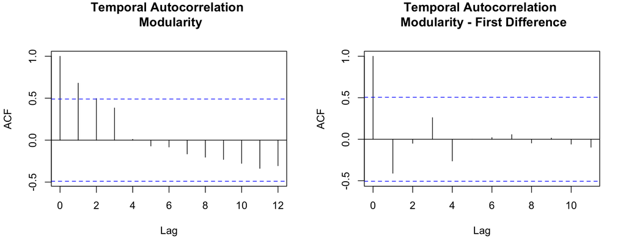

```r
par(mfrow=c(1,2))
acf(time.dat$TM, main="Temporal Autocorrelation \n Modularity")
acf(time.dat.change$TM.change[1:15], main="Temporal Autocorrelation \n Modularity - First Difference")
```

```r
par(mfrow=c(1,1))
```

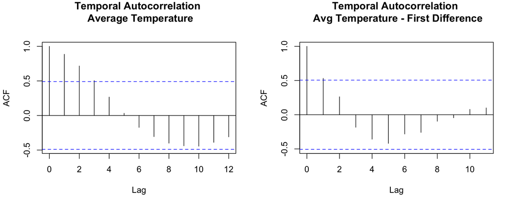

```r
par(mfrow=c(1,2))
acf(time.dat$Tavg, main="Temporal Autocorrelation \n Average Temperature")
acf(time.dat.change$Tavg.change[1:15], main="Temporal Autocorrelation \n Avg Temperature - First Difference")
```

```r
par(mfrow=c(1,1))
```

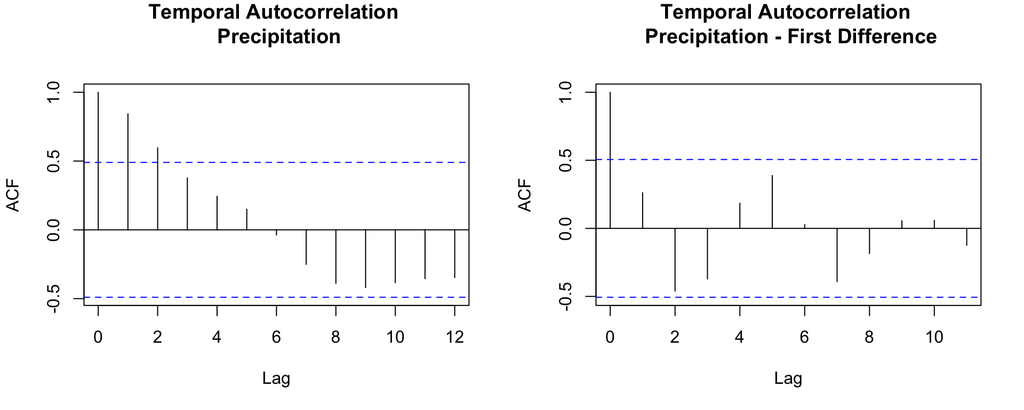

```r
par(mfrow=c(1,2))
acf(time.dat$Pr, main="Temporal Autocorrelation \n Precipitation")
acf(time.dat.change$Pr.change[1:15], main="Temporal Autocorrelation \n Precipitation - First Difference")
```

```r
par(mfrow=c(1,1))
```

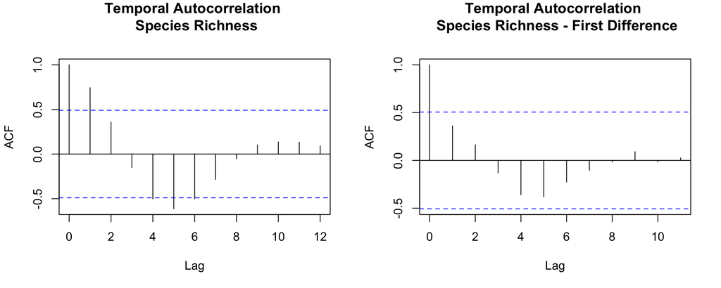

```r
par(mfrow=c(1,2))
acf(time.dat$SpC, main="Temporal Autocorrelation \n Species Richness")
acf(time.dat.change$SpC.change[1:15],  main="Temporal Autocorrelation \n Species Richness - First Difference")
```

```r
par(mfrow=c(1,1))
```

## References:

Newman M. and Girvan M. (2014). Finding and evaluating community structure in networks, Physical Review E 69, 026113

Strona, G., & Veech, J. A. (2015). A new measure of ecological network structure based on node overlap and segregation. Methods in Ecology and Evolution, 6(8), 907-915.